# Technical Analysis

### 6.6 Miscelleneous Plotting experiementations

### 6.6.1 GGPLOT - Exploration of Log Scale vs Continous Scale on Y for stock prices

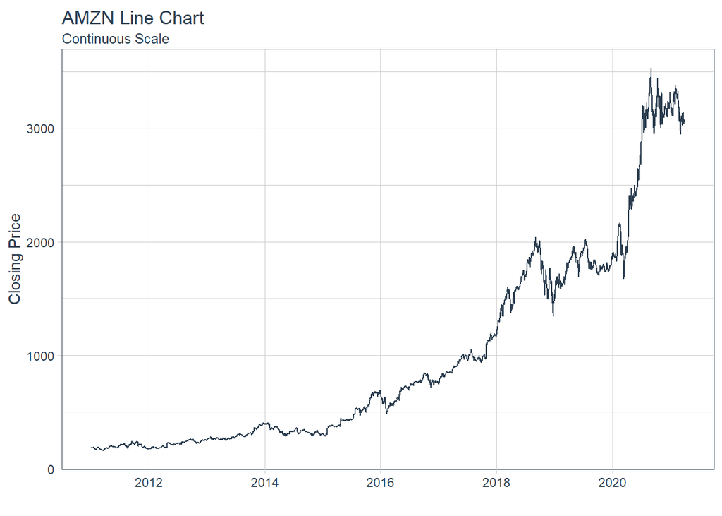

```r
AMZN %>%
    ggplot(aes(x = date, y = adjusted)) +
    geom_line(color = palette_light()[[1]]) +
    scale_y_continuous() +
    labs(title = "AMZN Line Chart",
         subtitle = "Continuous Scale",
         y = "Closing Price", x = "") +
    theme_tq()
```

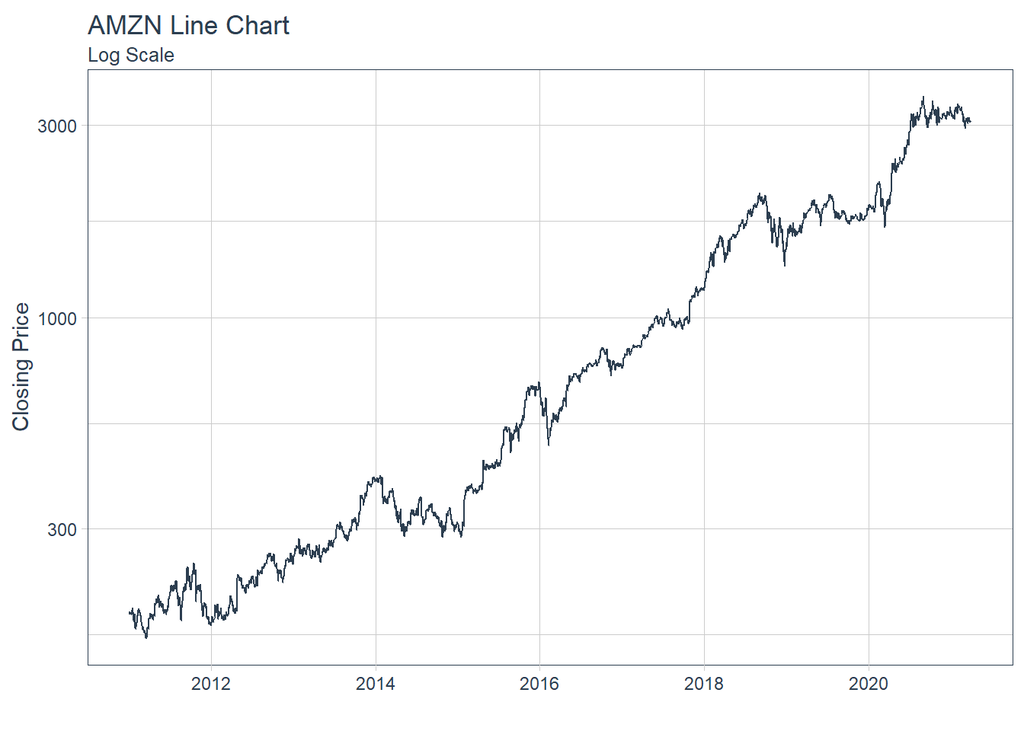

```r
AMZN %>%
    ggplot(aes(x = date, y = adjusted)) +
    geom_line(color = palette_light()[[1]]) +
    scale_y_log10() +
    labs(title = "AMZN Line Chart",
         subtitle = "Log Scale",
         y = "Closing Price", x = "") +
    theme_tq()
```

### 6.6.2 GGPLOT - Plotting Regression trendlines with geom_smooth

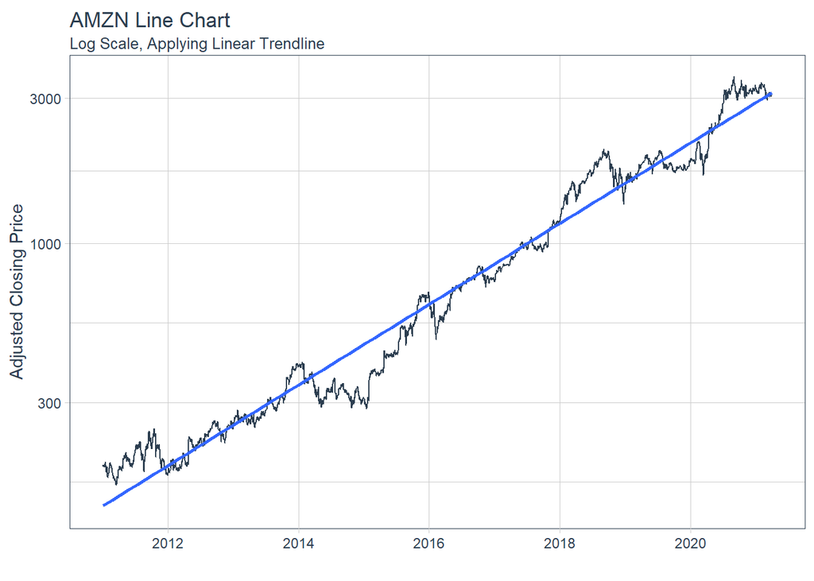

```r
AMZN %>%
    ggplot(aes(x = date, y = adjusted)) +
    geom_line(color = palette_light()[[1]]) +
    scale_y_log10() +
    geom_smooth(method = "lm") +
    labs(title = "AMZN Line Chart",
         subtitle = "Log Scale, Applying Linear Trendline",
         y = "Adjusted Closing Price", x = "") +
    theme_tq()
```

#### 6.6.3 Tidyquant Themes

#### 6.6.3.1 Testing with Dark Theme and thin lines

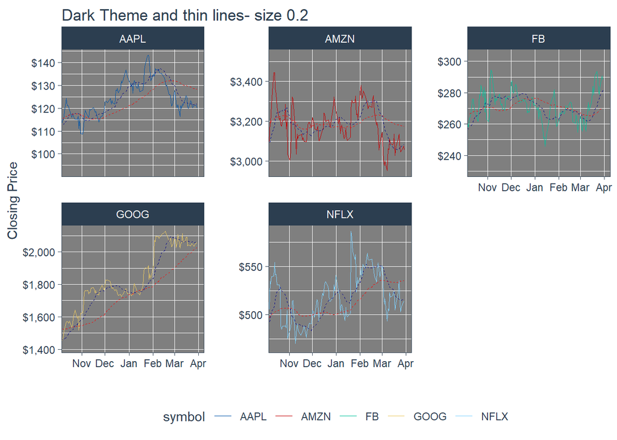

```r
n_mavg <- 50 # Number of periods (days) for moving average
FAANG %>%
    filter(date >= start - days(2 * n_mavg)) %>%
    ggplot(aes(x = date, y = close, color = symbol)) +
    geom_line(size = 0.2) +
    geom_ma(n = 15, color = "darkblue", size = 0.2) +
    geom_ma(n = n_mavg, color = "red", size = 0.2) +
    labs(title = "Dark Theme and thin lines- size 0.2",
         x = "", y = "Closing Price") +
    coord_x_date(xlim = c(start, end)) +
    facet_wrap(~ symbol, scales = "free_y") +
    theme_tq_dark() +
    scale_color_tq(theme = "dark") +
    scale_y_continuous(labels = scales::dollar)
```

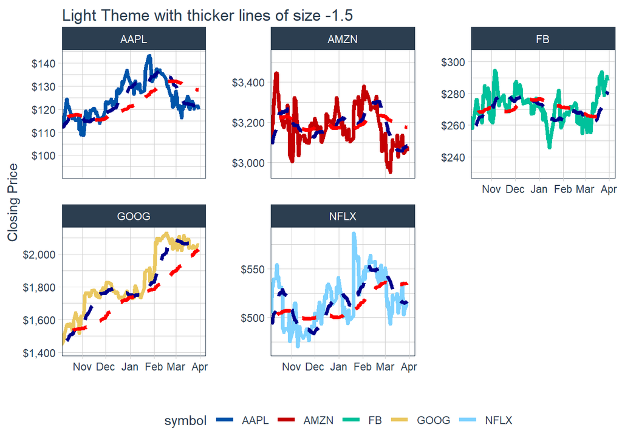

```r
n_mavg <- 50 # Number of periods (days) for moving average
FAANG %>%
    filter(date >= start - days(2 * n_mavg)) %>%
    ggplot(aes(x = date, y = close, color = symbol)) +
    geom_line(size = 1.5) +
    geom_ma(n = 15, color = "darkblue", size = 1.5) +
    geom_ma(n = n_mavg, color = "red", size = 1.5) +
    labs(title = "Light Theme with thicker lines of size -1.5",
         x = "", y = "Closing Price") +
    coord_x_date(xlim = c(start, end)) +
    facet_wrap(~ symbol, scales = "free_y") +
    theme_tq() +
    scale_color_tq(theme = "dark") +
    scale_y_continuous(labels = scales::dollar)
```

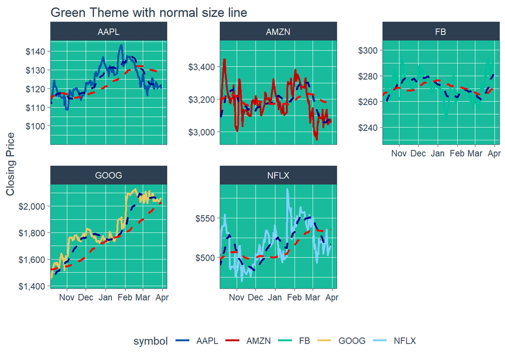

```r
n_mavg <- 50 # Number of periods (days) for moving average
FAANG %>%
    filter(date >= start - days(2 * n_mavg)) %>%
    ggplot(aes(x = date, y = close, color = symbol)) +
    geom_line(size = 1) +
    geom_ma(n = 15, color = "darkblue", size = 1) +
    geom_ma(n = n_mavg, color = "red", size = 1) +
    labs(title = "Green Theme with normal size line",
         x = "", y = "Closing Price") +
    coord_x_date(xlim = c(start, end)) +
    facet_wrap(~ symbol, scales = "free_y") +
    theme_tq_green() +
    scale_color_tq(theme = "dark") +
    scale_y_continuous(labels = scales::dollar)
```

*Key Learning* : THe other colour schemes - will invariably collide with one of the coloured lines - eg. in the last example above. The *white theme* with normal size line of 1 is good for single charts, and for faceted charts, white background with a fine line width of about 0.8 : still presents the information with better clarity, and should be used for overall approach.

## 7.0 Reflection- Conclusion/Key Learnings/Benefits of Interactivity in the Shiny App

A interactive implementation of the above would be able to bring much better user experience. Based on experimenting with various formats, graph and chart options i think :

a)Candle-stick is clearer for the user to read then barchart

b)Facets provide possiblity to read the details per stock ( when comparing a portofolio of stocks ) and should be provided as an additional option in addition to the typical ‘one chart’.

c)The default theme ‘white’ is much clearer than the fancier color schemes such as grey/green.

d)THe log-scale for y-axis eg. for stock prices although allowing more to be captured, can be misleading and is not recommended to be used for stock prices- especially for intepreting trends.

### 7.1 Interactive User Experience and Self Configuration of views

1. The user will be able select the range date for “zooming” down into the chart rather than hard-coding as above. Example a candlestick chart is not meaningful over multi-years.
2. The user will be able to use a drop-down menu to select the type of charts he wish to view both for single stock or groups of stock
3. The example shows the group stock analysis for 5 chosen stocks, in an interactive implementation the user will be able to decide which stocks he wants to view and compare as a group.
4. With an interactive add the portfolio mix can also be ‘configured’ for various scenarios

### 7.2 Finer details - Interacing with Chart Points.

With an interactive visualisation, the user is able to see more detail about the chart, by ‘hovering’ over the chart. Currently, all values have to be ‘read off’ the grid, and the user has to estimate the X and Y values based on the grid lines, instead of knowing the exact values.

## 8.0 Possible SHiny App Story Board for Stock Analysis

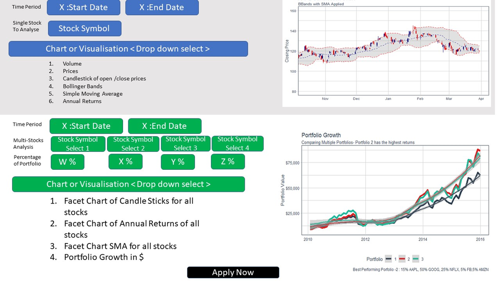

## 9.0 References

1)Tidyquant Reference Manual : https://cloud.r-project.org/web/packages/tidyquant/tidyquant.pdf : 5th March 2021

2)Introduction to TidyQuant https://cloud.r-project.org/web/packages/tidyquant/vignettes/TQ00-introduction-to-tidyquant.html

3)R Graphics Cook Book - Winston Chong

4)Workflow for : TidyQuant Portfolio Analysis https://cloud.r-project.org/web/packages/tidyquant/vignettes/TQ05-performance-analysis-with-tidyquant.html

5)Various Examples https://edav.info/tidyquant.html